# 21_fractal_area

## 21_fractal_area

#### Question

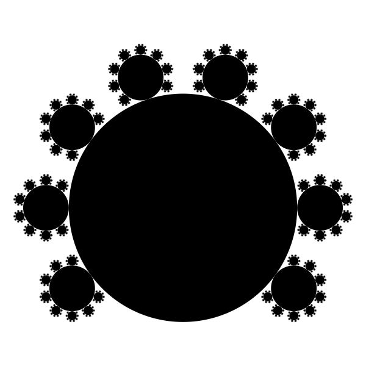

1. A fractal is generated such that the biggest circle has an area of 1 square units. The next generation has 8 circles, each with an area of $k=0.04$ square units. In the next generation of 64 circles, each has an area of $k^2=0.0016$, then 512 circles with area $k^3$ each, etc…

   Find the area of the fractal. The tolerance is $\pm 0.01$.

#### Question

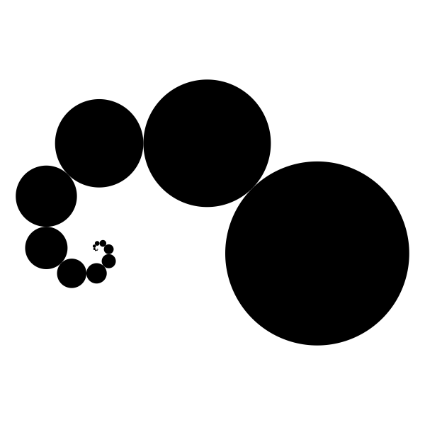

2. A fractal is generated such that the biggest circle has an area of 1 square units. The next generation has 1 circles, each with an area of $k=0.48$ square units. In the next generation of 1 circles, each has an area of $k^2=0.2304$, then 1 circles with area $k^3$ each, etc…

   Find the area of the fractal. The tolerance is $\pm 0.01$.

#### Question

[figure not shown]

3. A fractal is generated such that the biggest circle has an area of 1 square units. The next generation has 4 circles, each with an area of $k=0.09$ square units. In the next generation of 16 circles, each has an area of $k^2=0.0081$, then 64 circles with area $k^3$ each, etc…

   Find the area of the fractal. The tolerance is $\pm 0.01$.

#### Question

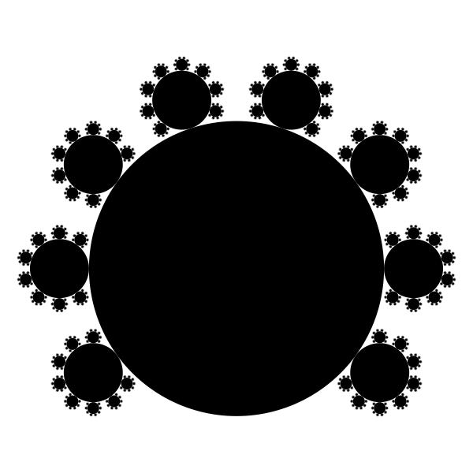

4. A fractal is generated such that the biggest circle has an area of 1 square units. The next generation has 8 circles, each with an area of $k=0.04$ square units. In the next generation of 64 circles, each has an area of $k^2=0.0016$, then 512 circles with area $k^3$ each, etc…

   Find the area of the fractal. The tolerance is $\pm 0.01$.

#### Question

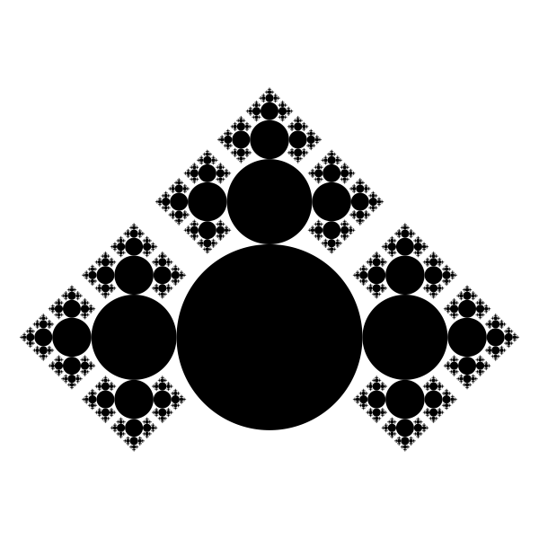

5. A fractal is generated such that the biggest circle has an area of 1 square units. The next generation has 3 circles, each with an area of $k=0.21$ square units. In the next generation of 9 circles, each has an area of $k^2=0.0441$, then 27 circles with area $k^3$ each, etc…

   Find the area of the fractal. The tolerance is $\pm 0.01$.

#### Question

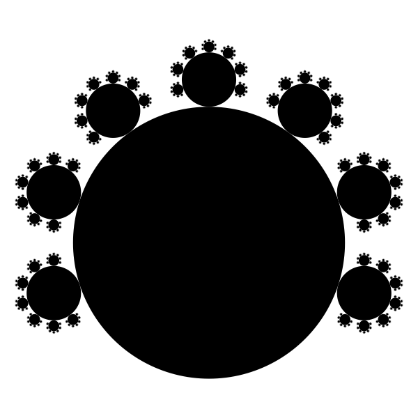

6. A fractal is generated such that the biggest circle has an area of 1 square units. The next generation has 7 circles, each with an area of $k=0.04$ square units. In the next generation of 49 circles, each has an area of $k^2=0.0016$, then 343 circles with area $k^3$ each, etc…

   Find the area of the fractal. The tolerance is $\pm 0.01$.

#### Question

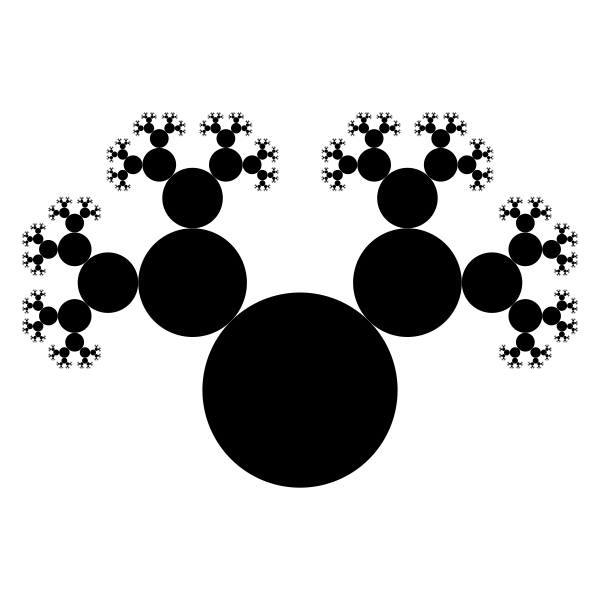

7. A fractal is generated such that the biggest circle has an area of 1 square units. The next generation has 2 circles, each with an area of $k=0.31$ square units. In the next generation of 4 circles, each has an area of $k^2=0.0961$, then 8 circles with area $k^3$ each, etc…

   Find the area of the fractal. The tolerance is $\pm 0.01$.

#### Question

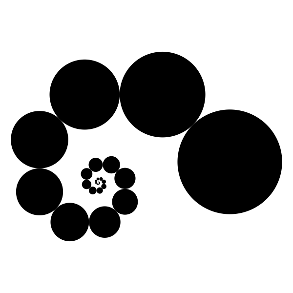

8. A fractal is generated such that the biggest circle has an area of 1 square units. The next generation has 1 circles, each with an area of $k=0.67$ square units. In the next generation of 1 circles, each has an area of $k^2=0.4489$, then 1 circles with area $k^3$ each, etc…

   Find the area of the fractal. The tolerance is $\pm 0.01$.